# Group Data Analysis

Group hisRüstü

## Preprocessing the Data

In the data, 81 provinces of Turkey contain information about first-hand and second-hand home price indexes. Migration movements in cities, economic movements throughout the country and some changes in cities, such as opening factories, are some of the factors that affect home price index data. Some packages need to be used to analyze the data. To start with, the packages are downloaded and the data is read from the csv file.

```r
evds = read.csv("https://raw.githubusercontent.com/pjournal/boun01g-hisrustu/gh-pages/housing_data_EVDS.csv")

url <- "https://raw.githubusercontent.com/pjournal/boun01g-hisrustu/gh-pages/TUR_1_sp.rds"

Turkey_Map <- readRDS(url(url, method="libcurl"))

TUR_fixed <- fortify(Turkey_Map)
```

**There are Turkish characters in the evds data. “convertName” function converts them to the English characters. However due to Excel version differences some computers use different special characters. So if our code gives an error in a different computer, it is probably due to this part.**

```r
convertName<-function(data,handLabel){
  data <- gsub(".*- (.+) -.*", "\\1", data)
  data <- gsub("\u008d", "i", data)
  data <- gsub("€", "C", data)
  data <- gsub("ž", "S", data)
  data <- gsub("Ÿ", "s", data)
  data <- gsub("\u0081", "u", data)
  data <- gsub("˜", "I", data)
  data <- gsub("§", "g", data)
  data <- gsub("”", "o", data)
  data <- paste(handLabel, data, sep="_")
  return(data)
}
```

After the 92nd row, rows give information about the numerical values.Therefore, numerical data was separated from the rows that contain information were put into another data set.

```r
datainfo = evds[c(92:1080),]
cityNames<-evds[c(95:258),2]
firstHandCityNames<-cityNames[c(1:82)]
secondHandCityNames<-cityNames[c(83:164)]
evds = evds[c(1:91),]
firstHandCityNames<-convertName(firstHandCityNames,"F")
secondHandCityNames<-convertName(secondHandCityNames,"S")
allNames= c("Tarih",firstHandCityNames,secondHandCityNames)
names(evds)<-allNames
```

The house price index data included data with zeros after the comma. To avoid these problems, zeros are cleared from the data after the comma.

```r
for(i in c(1:165)){
  evds[,i] <- gsub(",","",evds[,i])
}
evds[, c(2:165)] <- sapply(evds[, c(2:165)], as.numeric)
names(evds)[1] = "Date"
```

In order to convert the Date column to a date format, it was necessary to add days to the Date. That’s why the day was added to the Date column.

```r
evds$Date = paste(evds$Date,"01",sep="-")
evds = evds %>%
  mutate(Date=as.Date(Date, format="%Y-%m-%d")) %>%
  mutate(Year=year(Date), Month=month(Date))
```

In the data analysis process, a season column may be required to examine the relationship between price index data and seasons, so the season column was created.

```r
find_season <- function(mon){
  season = NULL

  if(between(mon, 3, 5)){
    season = "Spring"
  } else if(between(mon, 6, 8)){
    season = "Summer"
  } else if(between(mon, 9, 11)){
    season = "Fall"
  } else{
    season = "Winter"
  }

  return(season)
}
evds$Season = sapply(evds$Month, find_season)
```

When the data is checked carefully, there is some missing data. To guess what these missing data are: Total data was analyzed by collecting all data. As it is realized that it is equal, empty data (NA) are accepted as 0.

```r
evds[,c(2)] - rowSums(evds[,c(3:83)], na.rm = FALSE)
```

```
##  [1]  0  0 NA  0  0  0  0  0  0  0  0  0  0 NA  0  0  0  0  0  0  0  0  0  0  0
## [26]  0  0  0  0  0  0  0  0  0  0  0  0 NA  0  0 NA  0 NA  0  0  0  0  0  0  0
## [51]  0  0  0 NA  0  0  0  0  0  0  0  0  0  0  0  0  0  0  0  0  0  0  0  0 NA
## [76]  0  0  0  0  0  0  0  0  0  0  0  0  0  0  0  0
```

```r
evds[,c(2)] - rowSums(evds[,c(3:83)], na.rm = TRUE)
```

```
##  [1] 0 0 0 0 0 0 0 0 0 0 0 0 0 0 0 0 0 0 0 0 0 0 0 0 0 0 0 0 0 0 0 0 0 0 0 0 0 0
## [39] 0 0 0 0 0 0 0 0 0 0 0 0 0 0 0 0 0 0 0 0 0 0 0 0 0 0 0 0 0 0 0 0 0 0 0 0 0 0
## [77] 0 0 0 0 0 0 0 0 0 0 0 0 0 0 0
```

```r
evds[is.na(evds)] <- 0
```

## Analyzing the Data

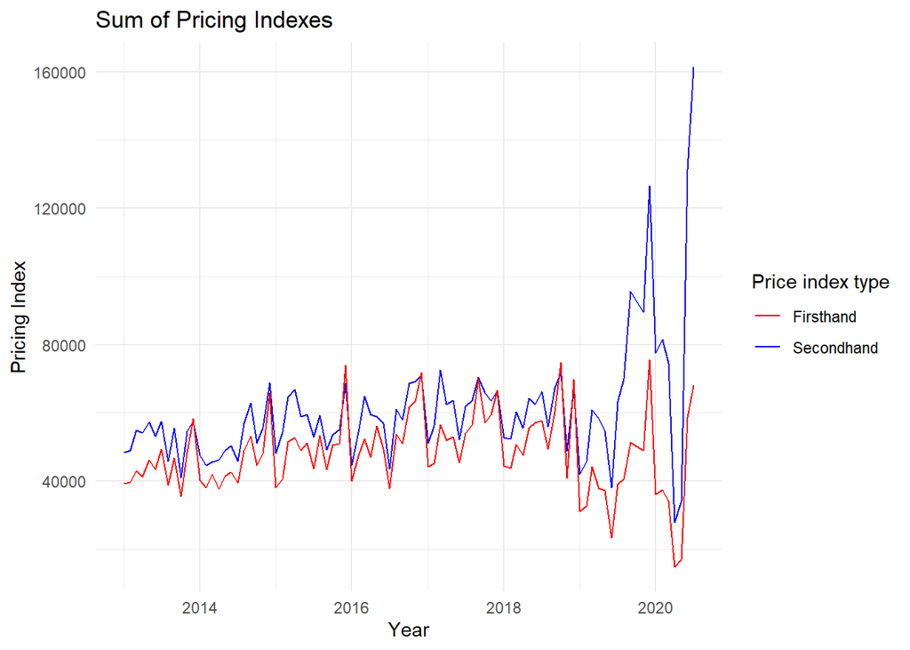

```r
ggplot(evds, aes(x=Date)) +
  geom_line(aes(y=S_Turkey, color="S")) +
  geom_line(aes(y=F_Turkey, color="F")) +
  theme_minimal() +
  ggtitle("Sum of Pricing Indexes") +
  labs(x = "Year", y = "Pricing Index")+
  scale_color_manual(name="Price index type", labels=c("Firsthand","Secondhand"),values=c("red","blue"))
```

In Turkey, the behavior of price index in general, the city has been interpreted by comparing the behavior of a relationship between them. As can be seen in the graph, the price index of Adana is similar to the price index data across the country. We cannot generalize for every city, but we can say that the same criteria are effective across the country.

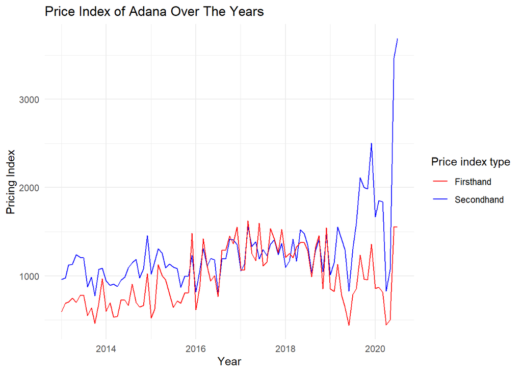

```r
ggplot(evds, aes(x=Date, color = Month)) +
  geom_line(aes(y=S_Adana, color="S1")) +
  geom_line(aes(y=F_Adana, color="F1")) +
  theme_minimal() +
  ggtitle("Price Index of Adana Over The Years") +
  labs(x = "Year", y = "Pricing Index")+
  scale_color_manual(name="Price index type", labels=c("Firsthand","Secondhand"),values=c("red","blue"))
```

In the two largest cities of Turkey, Ankara and Istanbul, the price index data were examined separately. When the data of the two cities are analyzed on the graph, the price index data of Istanbul is higher than Ankara’s. When the sum of the data of all cities is plotted, the total price index of Ankara and Istanbul is very high compared to other cities.

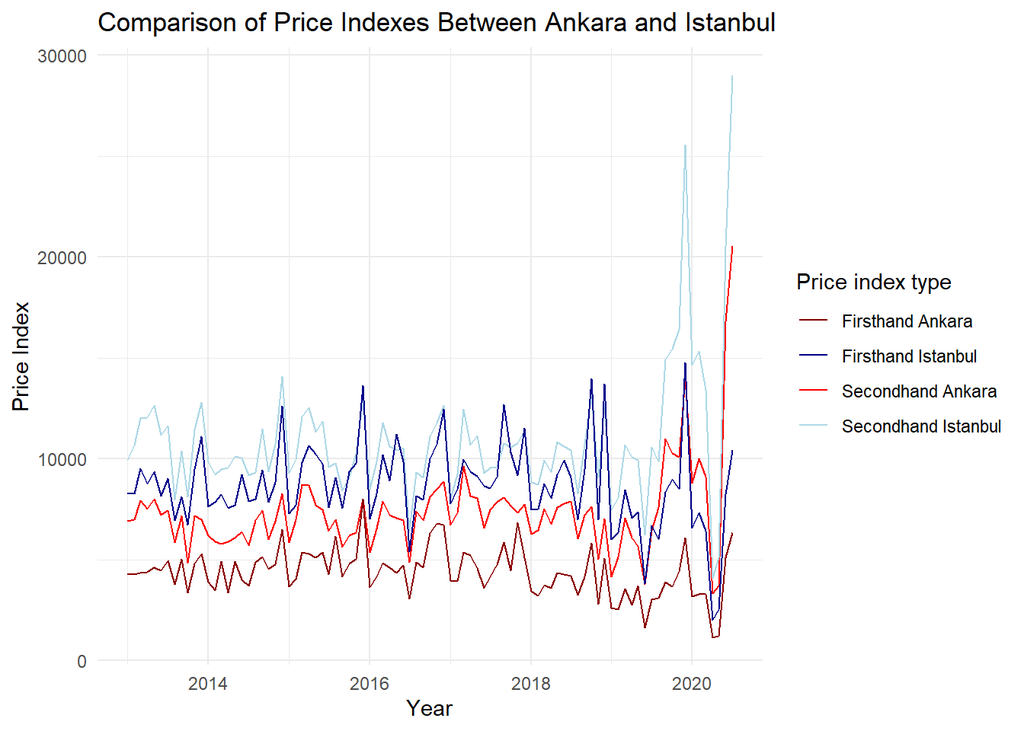

```r
ggplot(evds, aes(x=Date, color = Month)) +
  geom_line(aes(y=S_Ankara, color="S_Ankara")) +
  geom_line(aes(y=F_Ankara, color="F_Ankara")) +
  geom_line(aes(y=S_Istanbul, color="S_Istanbul")) +
  geom_line(aes(y=F_Istanbul, color="F_Istanbul")) +
  theme_minimal() +
  ggtitle("Comparison of Price Indexes Between Ankara and Istanbul") +
  labs(x = "Year", y = "Price Index")+
  scale_color_manual(name="Price index type", labels=c("Firsthand Ankara","Firsthand Istanbul", "Secondhand Ankara","Secondhand Istanbul"),values=c("darkred","darkblue","red","lightblue"))
```

## Plot Analysis

evds2 contains the percentage of the values that make up to the total, abnormal changes can be observed and a result can be concluded:

```r
evds2 = evds
evds2[,c(2:83)] = evds2[,c(2:83)]*100/evds2[,2]
evds2[,c(84:165)] = evds2[,c(84:165)]*100/evds2[,84]
```

In order to examine the house price index data of the Aegean Region and Antalya, whose population increases considerably during the summer season, some of the cities in the Aegean Region and Antalya were selected.

```r
ege_bolge <- evds[,c(1,10,14,43,13,61,166,167,168)]
head(ege_bolge)
```

```
##         Date F_Antalya F_Balikesir F_Izmir F_Aydin F_Mugla Year Month Season
## 1 2013-01-01      2101         639    2189     651     389 2013     1 Winter
## 2 2013-02-01      1896         693    2225     636     420 2013     2 Winter
## 3 2013-03-01      2374         751    2461     991     478 2013     3 Spring
## 4 2013-04-01      2188         847    2331     793     443 2013     4 Spring
## 5 2013-05-01      2535         858    2514     770     451 2013     5 Spring
## 6 2013-06-01      1883         804    2599     667     483 2013     6 Summer
```

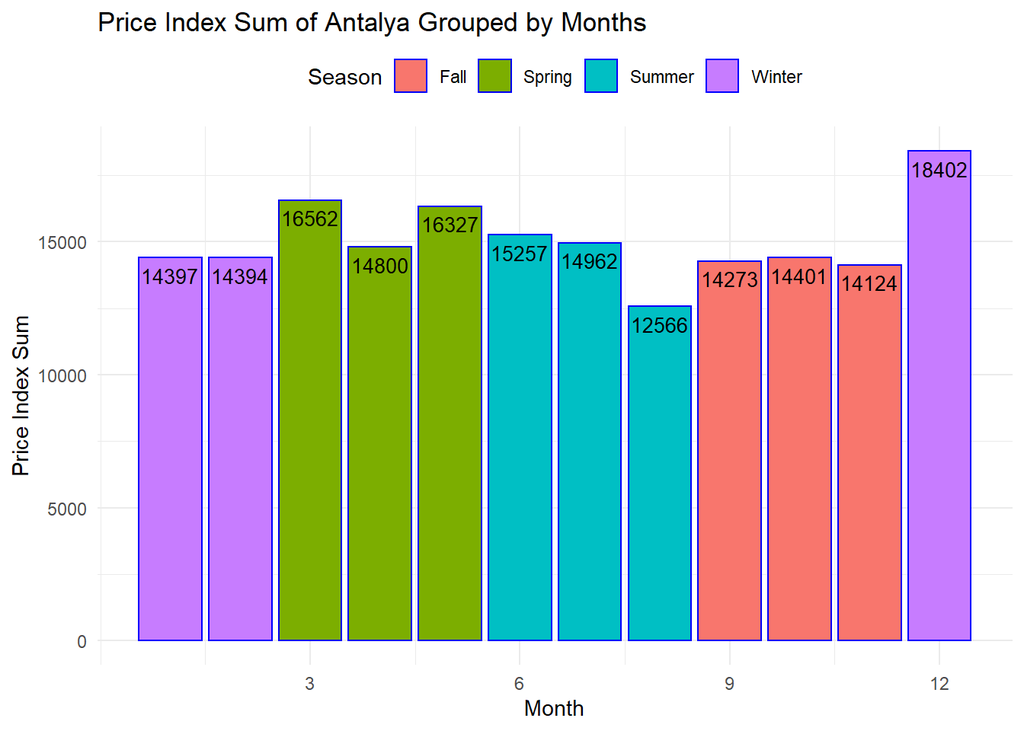

```r
ege_bolge %>%  group_by(Month,Season) %>% summarise(Sum = sum(F_Antalya)) %>%
  ggplot(data = ., aes(x = Month, y = Sum, fill = Season)) +
  geom_bar(stat="identity", position = position_dodge(), colour = "blue") +
  theme_minimal() +
  theme(legend.position="top")+
  labs(title = "Price Index Sum of Antalya Grouped by Months", y="Price Index Sum")+
  geom_text(aes(label=Sum), vjust=1.6, color="black",
      position = position_dodge(0.9), size=3.5)+
  scale_x_continuous(breaks=c(3,6,9,12))
```

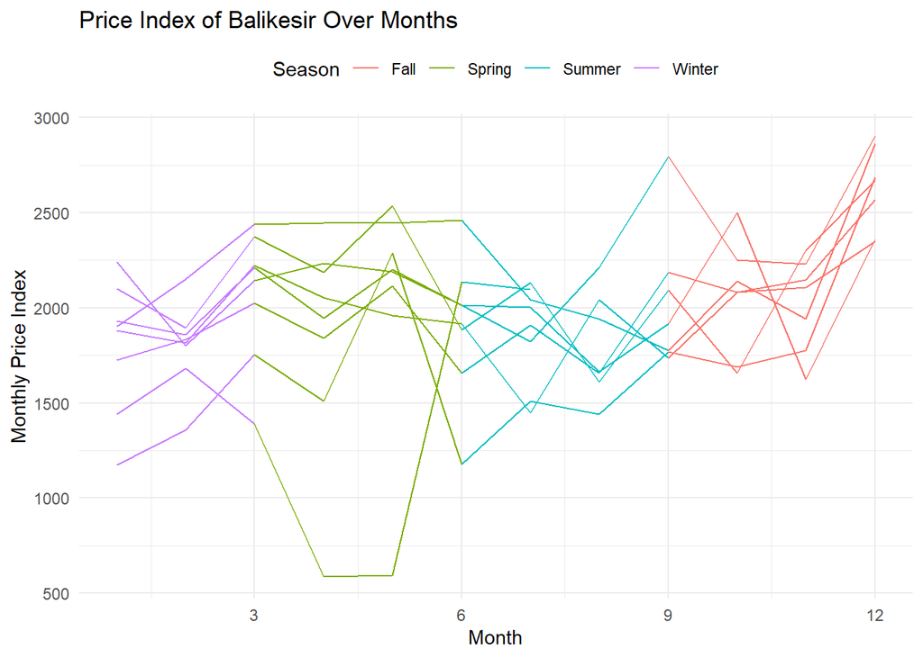

```r
ggplot(ege_bolge, aes(x=Month, y = ege_bolge[,c(2:2)], group = Year, colour = Season)) +
  geom_line() +
  theme_minimal() +
  theme(legend.position="top")+
  labs(title = "Price Index of Balıkesir Over Months",y="Monthly Price Index")+
  scale_x_continuous(breaks=c(3,6,9,12))
```

Total price index data by years and seasons by selected cities in the Aegean region with bar chart

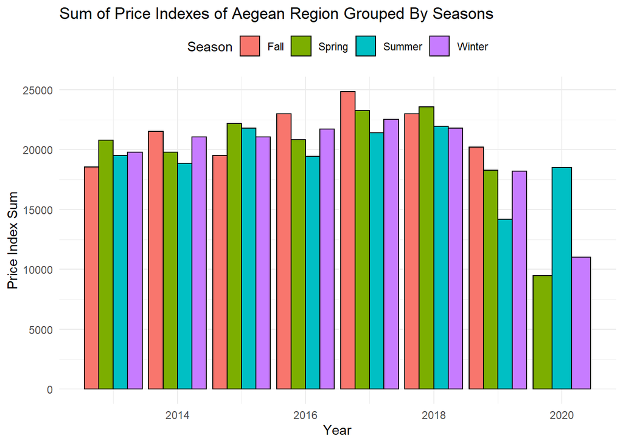

```r
#
ege_bolge %>% group_by(Year,Season) %>% summarise(SumData=sum(F_Antalya, F_Balikesir, F_Izmir, F_Aydin, F_Mugla)) %>%
    ggplot(data = ., aes(x = Year, y = SumData, fill = Season)) +
      geom_bar(stat="identity", position = position_dodge(), colour = "black") +
      theme_minimal() +
      theme(legend.position="top")+
   labs(title = "Sum of Price Indexes of Aegean Region Grouped By Seasons",y="Price Index Sum")
```

### Clustering by Housing Price Index

In this section, we tried to group cities according to how similar they are to each other and find similarity within a cluster using the k-means algorithm.

Moving on with the clustering, it is desired to analyze the sales behavior more logically by classifying data of the cities according to the similarities of the index movement. Therefore, all columns are scaled.

```r
changeClusterName <- function(cl){
  name = NULL

  if(cl == 1){
    name = "Cluster A"
  } else if(cl == 2){
    name = "Cluster B"
  } else if(cl == 3){
    name = "Cluster C"
  } else if(cl == 4){
    name = "Cluster D"
} else if(cl == 5){
    name = "Cluster E"
  }
  return(name)
}

createCluster<-function(data,clusterSize,scale=TRUE){

  if(scale){
    data<-scale(data)
  }
  set.seed(2)
  fit <- kmeans(t(data), clusterSize)
  fit$cluster = sapply(fit$cluster, changeClusterName)


  return(fit$cluster)
}


clusters = tibble(Turkey_Map@data$NAME_1)
names(clusters)=c("city")
clusterSize=5

clusters<-cbind(clusters,createCluster(evds[,c(3:83)],clusterSize))
clusters<-cbind(clusters,createCluster(evds[,c(3:83)],clusterSize,scale=FALSE))
clusters<-cbind(clusters,createCluster(evds[,c(85:165)],clusterSize))
clusters<-cbind(clusters,createCluster(evds[,c(85:165)],clusterSize,scale=FALSE))
clusters<-cbind(clusters,createCluster(evds[,c(85:165)]-evds[,c(3:83)],clusterSize))
names(clusters)<-c("city","First","nonScaleFirst","Second","nonScaleSecond","firstMinusSecond")
row.names(clusters)<-NULL
```

```r
mapPlot<-function(data,columnName,mapPositions){

mapPositions2<-cbind(mapPositions,data)

ab<-cbind(c(1:81),mapPositions2)
ab[,1]=as.character(ab[,1])
colnames(ab)[1]="id"

final_map <- left_join(TUR_fixed, ab, by = "id")


ggplot(final_map)+
  theme_minimal()+
  geom_polygon( aes_string(x = "long", y = "lat", group = "group", fill= columnName),
                color = "grey", alpha = 1/5) +
  coord_map()  +labs(title=paste(paste("Cities by",columnName),"Hand Housing Price Index"),fill= "Clusters")+
  theme(legend.position = "bottom") # change the legend position

}

mapPositions = tibble(Turkey_Map@data$NAME_1)
names(mapPositions)=c("city")
```

In the First Hand Price Index Plot according to the index movements, Antalya and İzmir are in the same cluster. Probably, the seasonal movements of being a summer vacation city are similar to each other. Adana and Ankara are in the same cluster. This cluster also includes many cities in the Central Anatolia Region. That’s why, there may be a regional effect in this cluster. Interestingly, Istanbul is in the same cluster with Şanlıurfa and Mardin. The probable reason for this may be the recent Syrian migration.

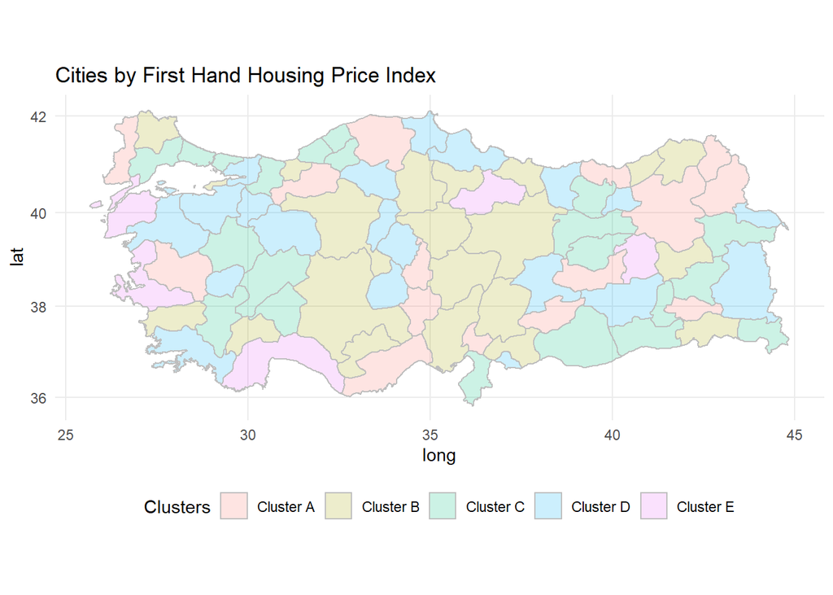

```r
mapPlot(clusters[,c(2:5)],"First",mapPositions)
```

In the Second Hand Price Index Plot it is seen that the movements in metropolitan cities are similar. Istanbul, Izmir and Antalya are in the same cluster. Adana and Ankara are in a different cluster. Although other cities look irregular, we see that nearby cities have the same colors. We can say that there is a regional effect, even if it is small.

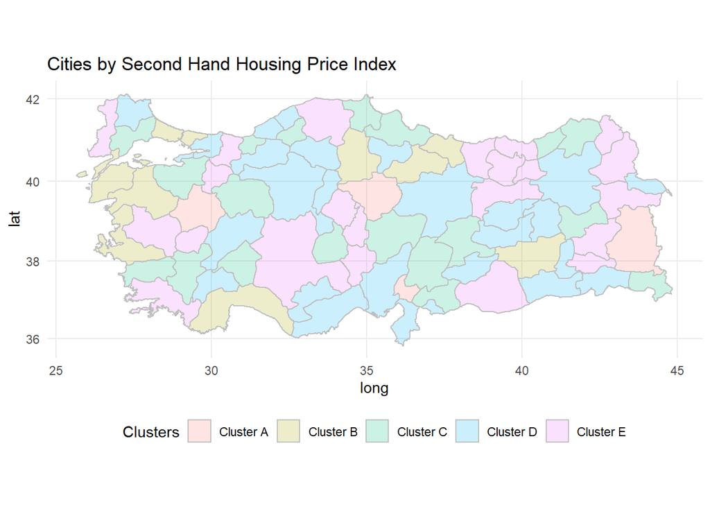

```r
mapPlot(clusters[,c(2:5)],"Second",mapPositions)
```

İstanbul, Ankara, Adana, Kayseri, Antalya, Bursa, Eskişehir, Mersin, and Van are among the largest 30 cities in Turkey. To see the difference between first-hand and second-hand prices, the means of their respective price index are calculated. As a common fact, first-hand prices are higher than the second-hand prices. However, Van shows an exceptional result as its second-hand price is higher. The plot is generated to show how large the difference is among these cities. Ankara and İstanbul are the leading cities in terms of the price gap, with Ankara on top and İstanbul the runner-up.

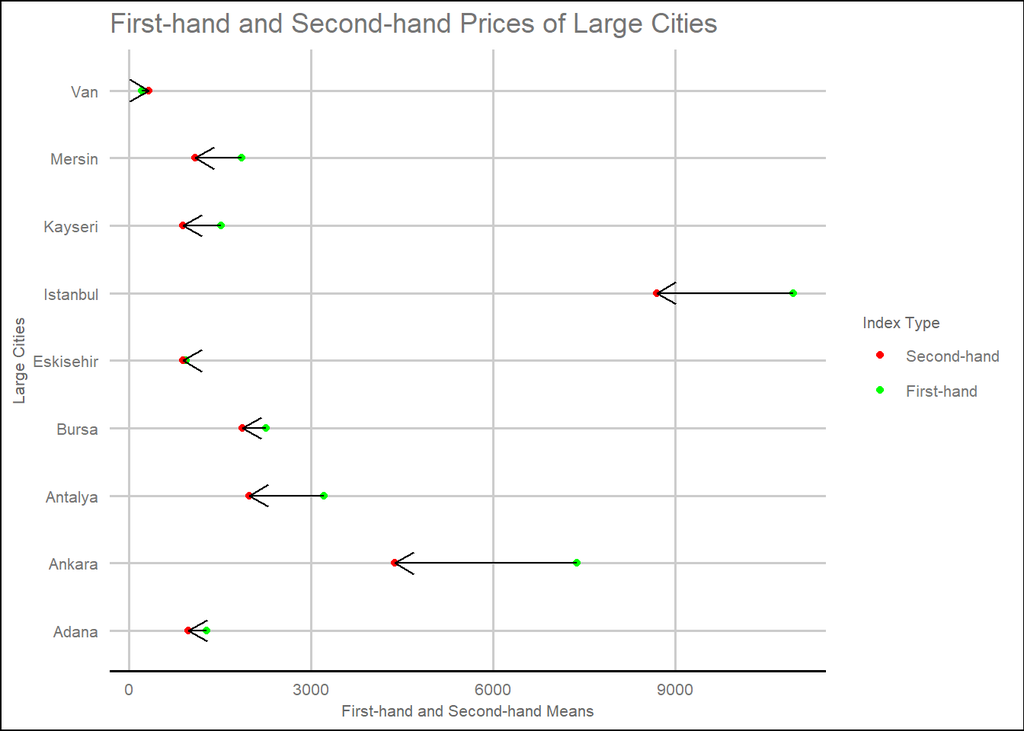

## Time Series Analysis

In order to conduct Time Series Analysis, the data should be converted to time series in format. Then we see that variance is increasing over time meaning that it’s multiplicative. Also, it may include seasonality. The series can be interpreted better by decomposition. The decomposed time series is plotted below.

```r
ts_F_Turkey <- ts(evds$F_Turkey,freq=12,start = 2013)
ts_F_Turkey
```

```
##        Jan   Feb   Mar   Apr   May   Jun   Jul   Aug   Sep   Oct   Nov   Dec
## 2013 39163 39521 43052 41233 46049 43345 49224 38817 46778 35363 48255 58329
## 2014 40155 38074 41983 37555 41456 42620 39373 48828 53039 44499 48128 65844
## 2015 37971 40662 51487 52598 49001 51202 43623 53218 43333 50564 50976 74032
## 2016 40077 47409 52374 46908 56043 49354 37829 53784 50972 61677 63467 71792
## 2017 44235 45215 56376 51988 52976 45433 53949 56498 70019 56994 59354 66661
## 2018 44363 43713 50701 47534 55502 57064 57617 49362 60219 74815 40821 69861
## 2019 31048 32648 44163 37784 37246 23265 38931 40634 51393 50181 48909 75480
## 2020 36040 37303 34089 14848 16860 58632 67937
```

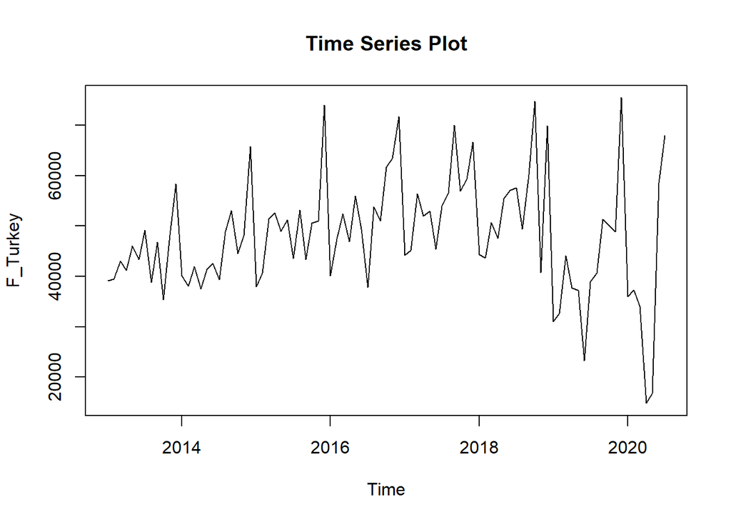

```r
plot(ts_F_Turkey, main = "Time Series Plot", ylab = "F_Turkey")
```

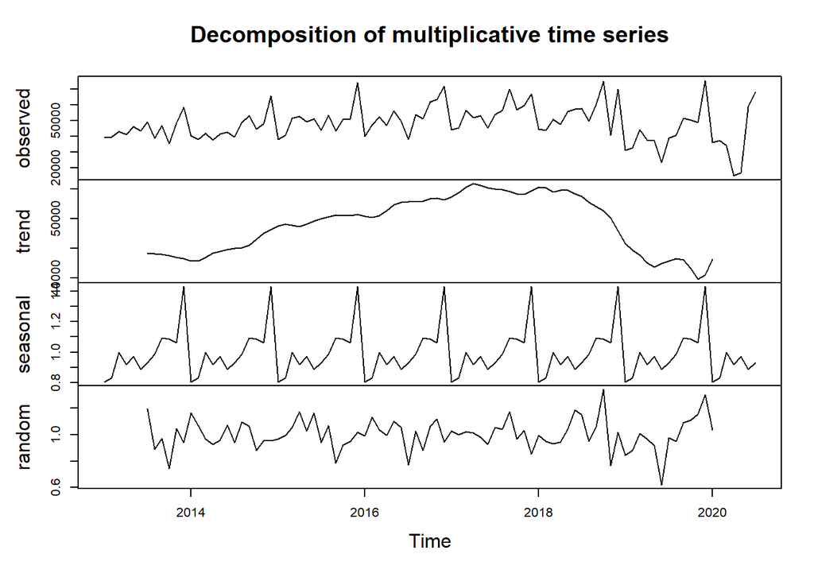

```r
plot(decompose(ts_F_Turkey, type = "multiplicative"))
```

After the time series visualization and analysis, the auto correlation function of the time series is plotted. The auto correlation values peak at lag 12 and at lag 24, which means that there is a monthly seasonality factor.

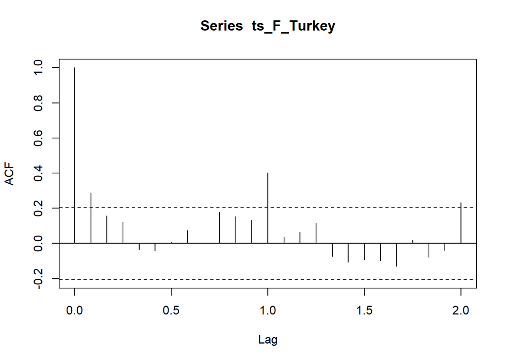

```r
acf(ts_F_Turkey, lag.max = 24)
```

Observing the time series plot of the data, it’s seen that variance changes over time. Thus, a transformation is needed due to this non-stationarity. After the logarithmic transformation, the change is visible on the graph below.

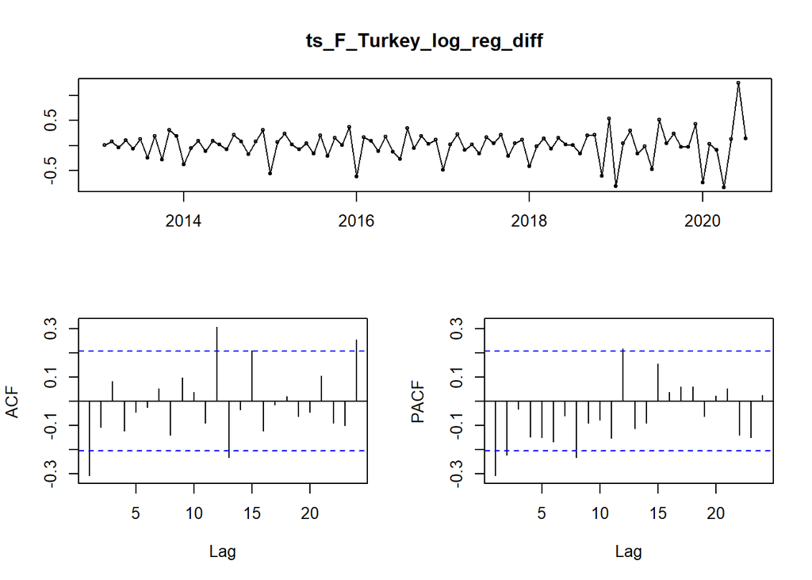

```r
ts_F_Turkey_log <- ts(log(evds$F_Turkey),freq=12,start = 2013)

ts_F_Turkey_log_reg_diff=diff(ts_F_Turkey_log)
tsdisplay(ts_F_Turkey_log_reg_diff, lag.max = 24)
```

After logarithmic transformation, it’s seen that differencing is needed; therefore, one order regular differencing is applied. In the figure below, you can see the significant acf values at different lags. They peak at lags 12, 24 and so on. This pattern means that seasonality and seasonal differencing is needed.

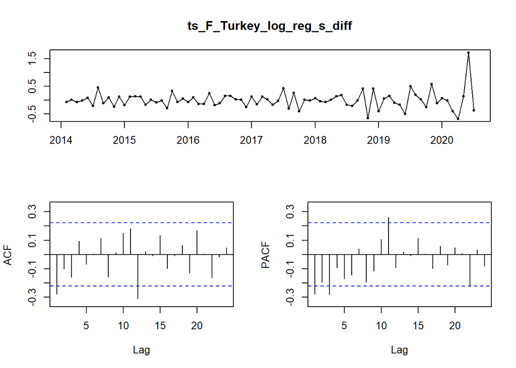

```r
ts_F_Turkey_log_reg_s_diff=diff(ts_F_Turkey_log_reg_diff,12)
tsdisplay(ts_F_Turkey_log_reg_s_diff, lag.max = 24)
```

ACF and PACF plots of the time series suggest ARIMA (1,0,0)(2,0,0) 12.

```r
model_first <- Arima(ts_F_Turkey_log, order=c(1,0,0), seasonal=c(2,0,0))
model_first
```

```
## Series: ts_F_Turkey_log
## ARIMA(1,0,0)(2,0,0)[12] with non-zero mean
##
## Coefficients:
##          ar1    sar1    sar2     mean
##       0.4208  0.3298  0.2609  10.7219
## s.e.  0.0992  0.1266  0.1511   0.0784
##
## sigma^2 estimated as 0.0504:  log likelihood=6.59
## AIC=-3.18   AICc=-2.48   BIC=9.37
```

The statistical evidence can be found with the inspection of the residuals of the model. The residuals should be normal and the Q-Q plot can be used for inspection.

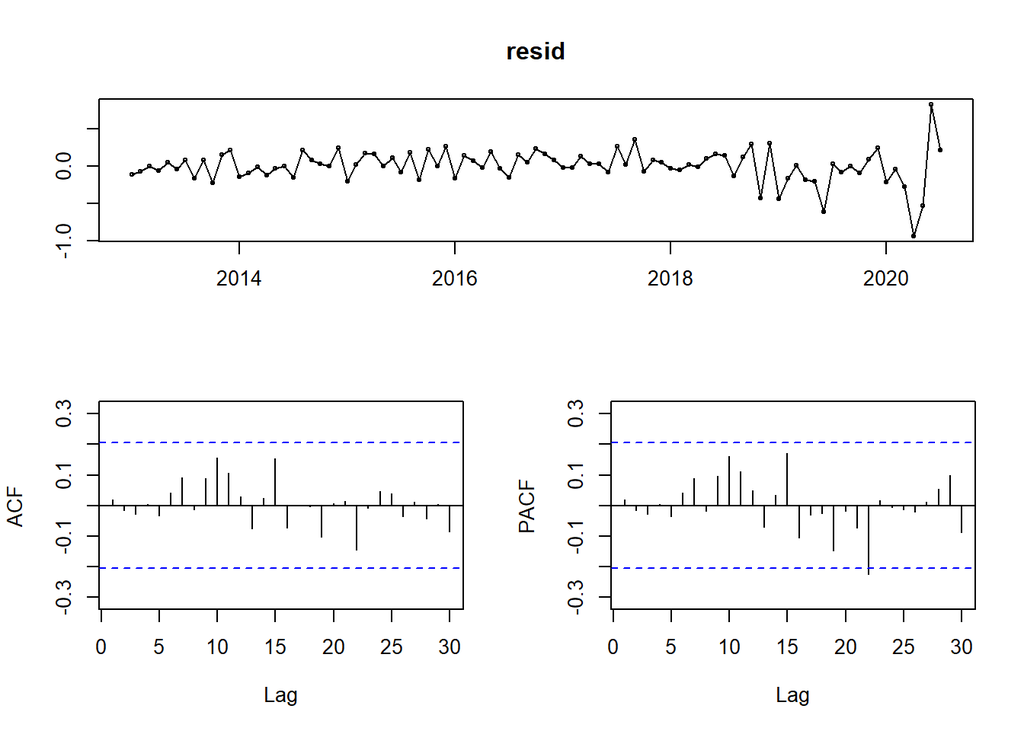

```r
resid <- model_first$residuals
tsdisplay(resid)
```

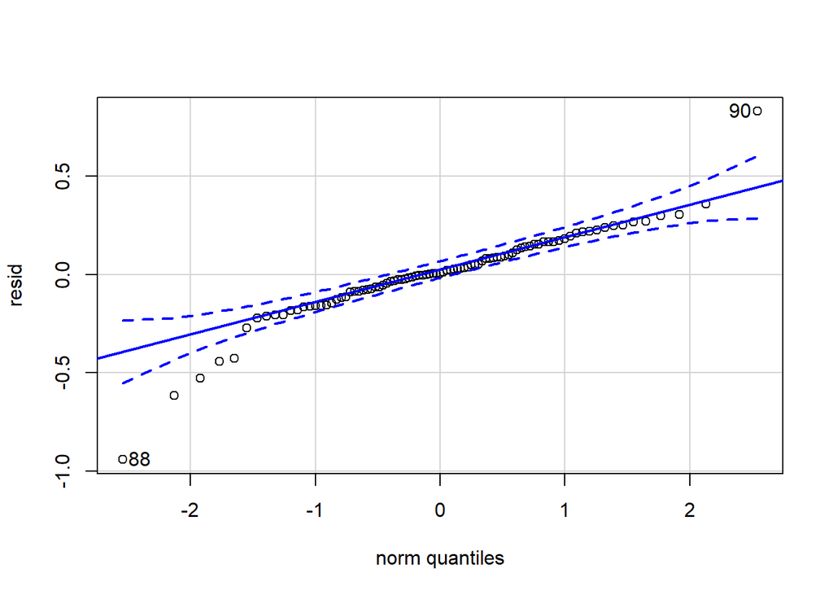

```
## [1] 88 90
```

```r
qqPlot(resid)
```

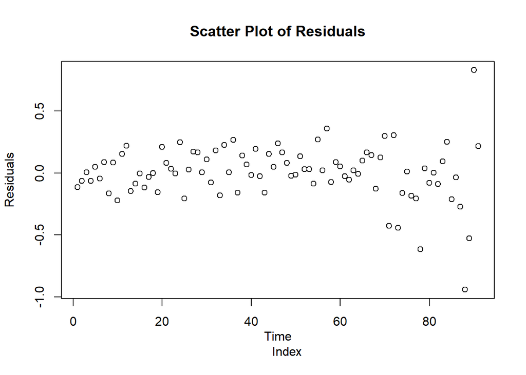

```r
plot(c(model_first$residuals), main="Scatter Plot of Residuals", xlab = "Time
     Index", ylab = "Residuals")
```

## Time Series - Future Prediction (2020-2)

We’re good to go with the model. Therefore, we can now predict next months. Let’s predict the second half of 2020.

```r
forecast_sales=forecast(model_first , h=5)
real_forecast=exp(forecast_sales$mean)
real_forecast
```

```
##           Aug      Sep      Oct      Nov      Dec
## 2020 52731.49 54541.32 55008.15 45789.22 60352.06
```

Note that to make the multiplicative model additive, we conducted a log transformation, hence, they are transformed them back to the obtained forecast. Plot the forecast to see the pattern.

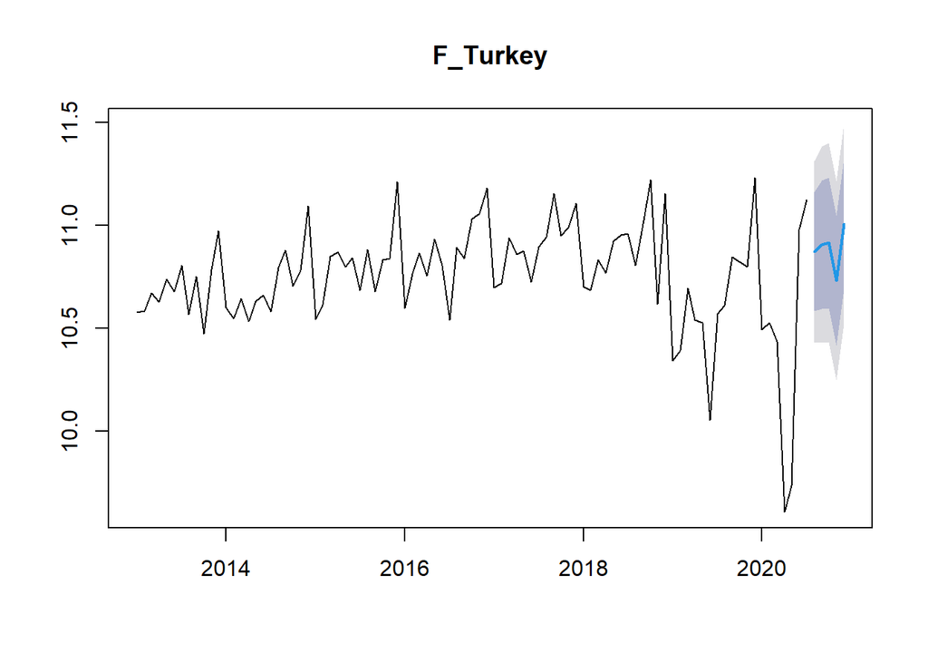

```r
plot(forecast(model_first, h=5), main="F_Turkey")
```

Similar procedures are followed and predictions are made for the secondhand sales level(“S_Turkey”).

```
## Series: ts_S_Turkey_log
## ARIMA(2,1,2)(1,0,0)[12]
##
## Coefficients:
##          ar1      ar2      ma1      ma2    sar1
##       0.4310  -0.2886  -0.8297  -0.0815  0.3340
## s.e.  0.3686   0.1972   0.3723   0.3589  0.1389
##
## sigma^2 estimated as 0.04838:  log likelihood=9.71
## AIC=-7.41   AICc=-6.4   BIC=7.59
```

```
##          Point Forecast    Lo 80    Hi 80    Lo 95    Hi 95
## Aug 2020       11.36394 11.08206 11.64581 10.93285 11.79503
## Sep 2020       11.15541 10.82650 11.48433 10.65239 11.65844
## Oct 2020       11.20115 10.87181 11.53048 10.69747 11.70482
## Nov 2020       11.30393 10.97417 11.63369 10.79960 11.80825
## Dec 2020       11.45304 11.12303 11.78306 10.94833 11.95776
```

```r
real_forecast_second
```

```
##           Aug      Sep      Oct      Nov      Dec
## 2020 86157.88 69941.50 73214.24 81139.59 94187.71
```

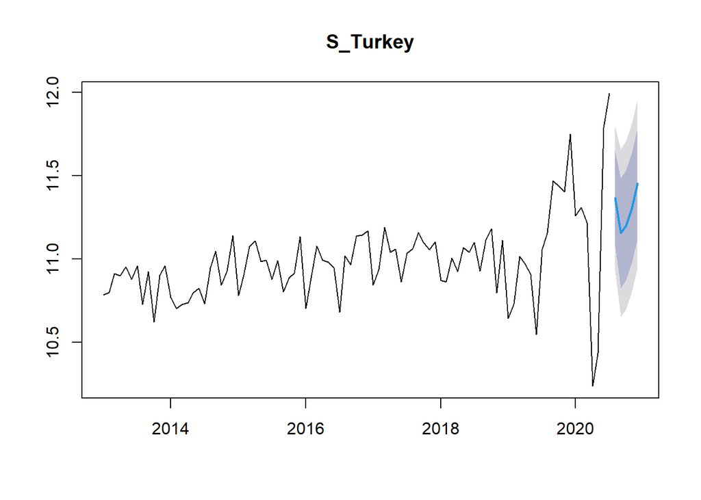

```r
plot(forecast(model_second, h=5), main="S_Turkey")
```

```
## Series: ts_F_Antalya_log
## ARIMA(0,1,1)(2,0,0)[12]
##
## Coefficients:
##           ma1    sar1    sar2
##       -0.8547  0.0973  0.3131
## s.e.   0.0619  0.1331  0.1545
##
## sigma^2 estimated as 0.05123:  log likelihood=5.55
## AIC=-3.09   AICc=-2.62   BIC=6.91
```

```
##          Point Forecast    Lo 80    Hi 80    Lo 95    Hi 95
## Aug 2020       7.204174 6.914115 7.494233 6.760567 7.647780
## Sep 2020       7.268085 6.974981 7.561190 6.819821 7.716350
## Oct 2020       7.346888 7.050769 7.643007 6.894013 7.799763
## Nov 2020       7.216697 6.917594 7.515800 6.759258 7.674136
## Dec 2020       7.373940 7.071883 7.675998 6.911983 7.835898
```

```r
real_forecast_f_antalya
```

```
##           Aug      Sep      Oct      Nov      Dec
## 2020 1345.033 1433.803 1551.361 1361.983 1593.902
```

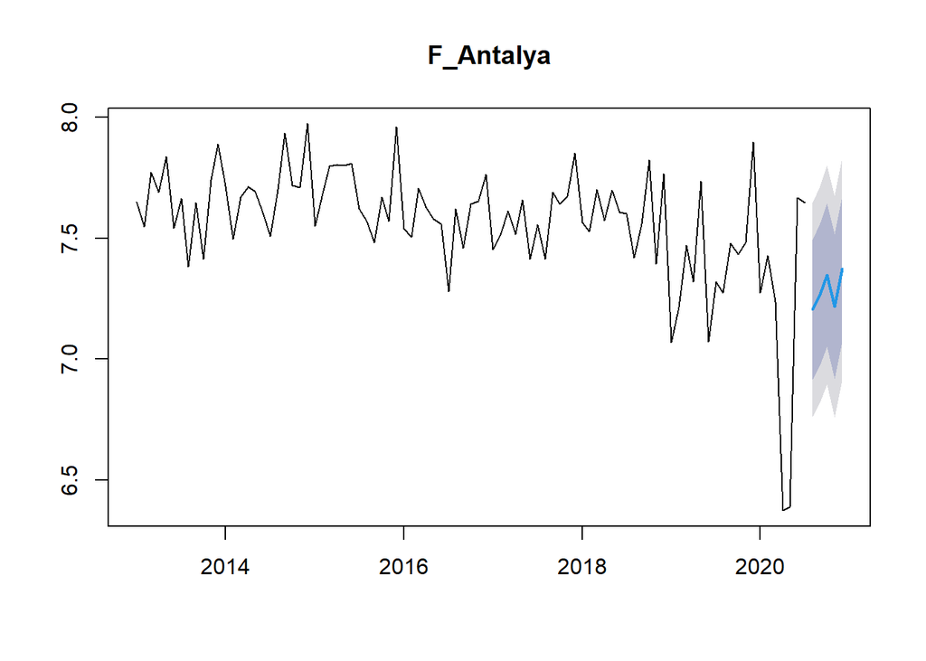

```r
plot(forecast(model_first_antalya, h=5), main="F_Antalya")
```

## Time Series - Future Prediction (2020 Plots)

PS: Note that to make the multiplicative model additive we made log transformation, so we will transform them back to obtained forecasts.

### Turkey’s First Sales in 2020

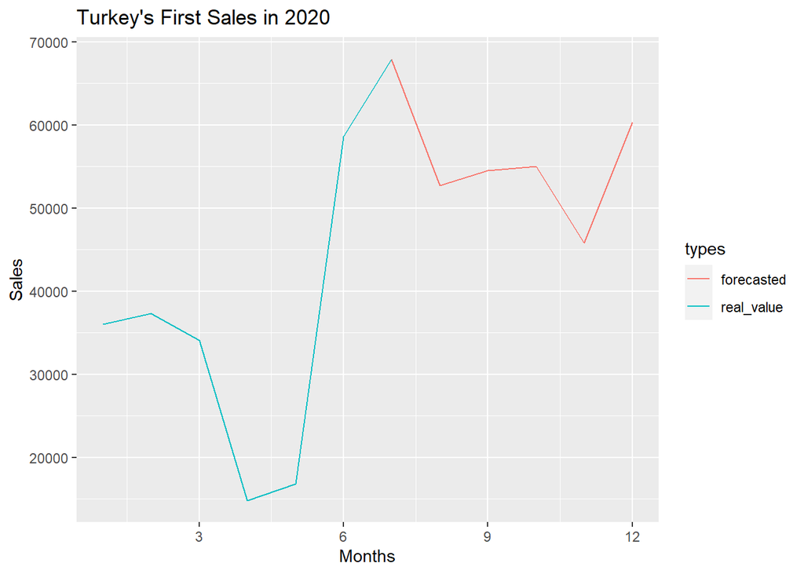

```r
t_first_2020 <- c(ts_F_Turkey[85:91], real_forecast)
plot_list = list(real_value = data.frame(x=c(1:7), y=t_first_2020[1:7]),
                  forecasted = data.frame(x=c(7:12), y=t_first_2020[7:12]))
ggplot(bind_rows(plot_list, .id="types"), aes(x, y, colour=types)) + geom_line() + ggtitle("Turkey's First Sales in 2020")+ scale_x_continuous(breaks=c(3,6,9,12)) +labs(x="Months", y="Sales")
```

### Turkey’s Secondhand Sales in 2020

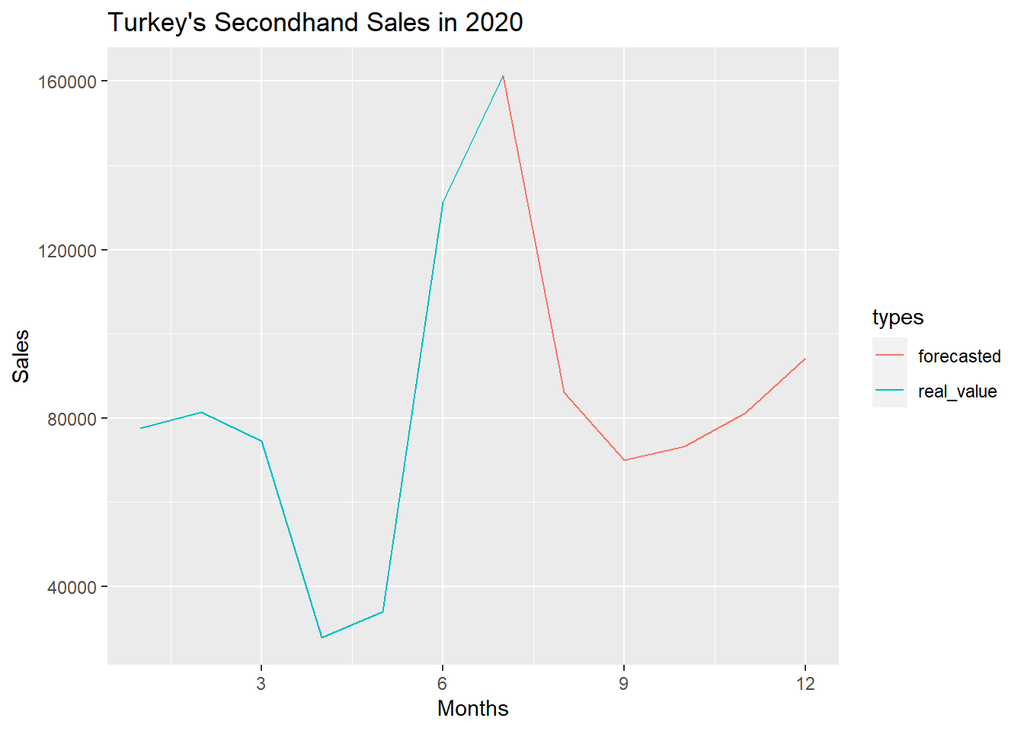

```r
t_second_2020 <- c(ts_S_Turkey[85:91], real_forecast_second)
plot_list = list(real_value = data.frame(x=c(1:7), y=t_second_2020[1:7]),
                  forecasted = data.frame(x=c(7:12), y=t_second_2020[7:12]))
ggplot(bind_rows(plot_list, .id="types"), aes(x, y, colour=types)) + geom_line() + ggtitle("Turkey's Secondhand Sales in 2020")+ scale_x_continuous(breaks=c(3,6,9,12)) +labs(x="Months", y="Sales")
```

### Antalya’s First Sales in 2020

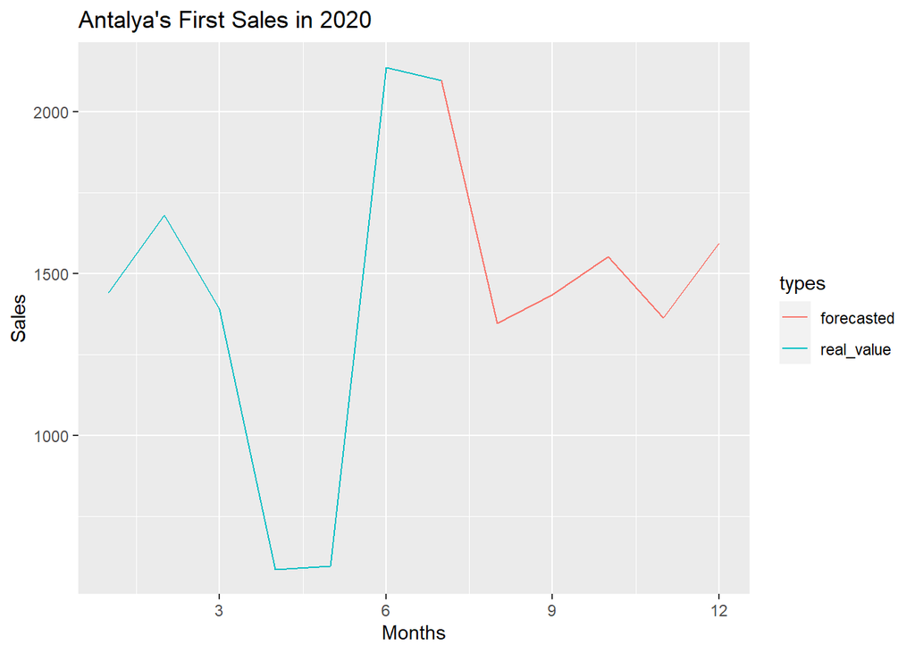

```r
antalya_2020 <- c(ts_F_Antalya[85:91], real_forecast_f_antalya)
plot_list = list(real_value = data.frame(x=c(1:7), y=antalya_2020[1:7]),
                  forecasted = data.frame(x=c(7:12), y=antalya_2020[7:12]))
ggplot(bind_rows(plot_list, .id="types"), aes(x, y, colour=types)) + geom_line() + ggtitle("Antalya's First Sales in 2020") + scale_x_continuous(breaks=c(3,6,9,12)) +labs(x="Months", y="Sales")
```